# Group 17 Group assignment 2

Understand our goal - content map

perceptual mapping (final product) <- multidimensional scaling <- dissimilarity matrix <- similarity matrix <- co-occurence and lift

# Load libraries

```r
library(jsonlite)

library(tidyverse)
library(skimr)
library(janitor)

# library(itertools)
library(openxlsx)

library(ggplot2)
library(ggrepel)
```

# Read Data

data1 -> 5 core data2 -> full reviews data data3 -> full metadata

```r
data1 <- stream_in(file("Software_5.json")) %>% clean_names()
```

[output not shown]

```r
data2 <- stream_in(file("Software.json")) %>% clean_names()
```

[output not shown]

[output cut: 866 more lines]

[output not shown]

```r
# reviews <- data[,c(1:10)] # get only the first ten variables

data3 <- stream_in(file("meta_Software.json")) %>% clean_names()
```

[output not shown]

# Clean data3

there are some brand patterns like “by ” - we need to get rid of those

```r
data3$brand <- str_replace(data3$brand,"by","")
data3$brand <- str_replace(data3$brand,"[\\n]","")
data3$brand <- str_replace(data3$brand,"[\\n]","")
data3$brand <- str_trim(data3$brand)
```

# Analysis

I tried on the sample first, now we merge data3 with the real full data remove some na

```r
merged1 <- merge(data2, data3, by='asin') %>% drop_na("brand","review_text")

# merged1_c <- merged1 %>%
#   select(asin, brand, review_text)
```

## Pick top 30 brands

```r
top30 <- merged1 %>%
  clean_names() %>%
  group_by(brand) %>%
  summarize(n=n()) %>%
  ungroup() %>%
  arrange(desc(n)) %>%
  top_n(31)
top30 <- as.list(top30$brand)
top30 <- top30[-22]
```

## analyze the cooccurrences of top 30

if we want to find brand A, then we need filter brand=‘A’, then find any non-A brands in review-text

try and build a starting point here

*readme* 1. str_count would count multiple times the same word - if we are taking semantics into account, multiple mentions means strong cooccurrence and it makes sense. Otherwide we need to use sum(str_detect) 2. about the brands list, normally people wouldn’t type “Amazon Digital Services LLC” out entirely, so we need to make some editing for some brands

**changelog** Amazon Digital Service LLC -> Amazon AVAST Software s.r.o -> Avast Nova Development US -> Nova

```r
# simplify brand name for some
top30[4] <- "Amazon"
top30[12] <- "Nova"
top30[16] <- "Avast"
top30[23] <- "Smith"
top30[28] <- "Parallels"
```

```r
# first find reviews under the top 30 brands
count <- c()
brand1 <- c()
brand2 <- c()
for (i in top30) {
  filter1 <- merged1 %>%
    filter(brand==i) %>%
    select(brand,review_text)


  for (j in top30) {
    cooc <- sum(str_count(filter1$review_text,j))
    count <- append(count, cooc)

    brand1 <- append(brand1, i)
    brand2 <- append(brand2, j)

  }

}
result <- cbind.data.frame(brand1, brand2, count)
print(result)
```

```
##                   brand1               brand2 count
## 1                 Intuit               Intuit 21050
## 2                 Intuit            Microsoft  2339
## 3                 Intuit             Symantec    12
## 4                 Intuit               Amazon  6306
## 5                 Intuit            H&R Block  1985
## 6                 Intuit                Corel     0
## 7                 Intuit            Kaspersky     4
## 8                 Intuit               Encore     0
## 9                 Intuit              Webroot     8
## 10                Intuit               McAfee     7
## 11                Intuit        Nuance Dragon     1
## 12                Intuit                 Nova     6
## 13                Intuit                Apple   524
## 14                Intuit                Roxio     7
```

[output cut: 886 more lines]

```r
matrix1 <- pivot_wider(result, id_cols = brand1, names_from = brand2, values_from = count)
write.xlsx(matrix1,"matrix1.xlsx", asTable = T)
```

The problem with the previous results is, the occurrence for (A,B) is the same as (B,A) - so we need to add them up together; that’s the *+ side*

however, in the examples, the matrix and rows and columns under the same brand - we will keep this in mind

```r
# now we find the final cooccurrence

result %>%
  mutate(brand_key = paste(brand1, brand2, sep='-'),
         brand_key = unname(
           sapply(brand_key, function(x) {
             paste(sort(trimws(strsplit(x[1],'-')[[1]])), collapse='-')
           })
          )
         ) %>%
  group_by(brand_key) %>%
  summarize(count = sum(count, na.rm=TRUE)) -> cooccurrence
print(cooccurrence)
```

```
## # A tibble: 465 x 2
##    brand_key         count
##    <chr>             <int>
##  1 Acronis-Acronis    3659
##  2 Acronis-Adobe        11
##  3 Acronis-Amazon      180
##  4 Acronis-Apple        11
##  5 Acronis-Avanquest    12
##  6 Acronis-Avast         0
##  7 Acronis-Corel         2
##  8 Acronis-Cyberlink     0
##  9 Acronis-Encore        1
## 10 Acronis-Garmin        0
## # … with 455 more rows
```

## Calculate the Lift

the assignment asks us to use P(A,B)/(P(A)*P(B)) - this is different than the slides! P(X) is the probability of occurrence of term X in a given review

```r
merged1 %>%
  subset(select=c(review_text)) -> merged11

nrow(merged11) -> total_rows

# P(A)/P(B)
brand <- c()
p_a <- c()

for (i in top30) {

  sum(str_count(merged11$review_text,i)) -> freq

  pa <- freq/total_rows

  brand <- append(brand, i)
  p_a <- append(p_a,pa)
}

table1 <- cbind.data.frame(brand, p_a)
```

now we need P(A,B)/(P(A)*P(B)) - table1, cooccurrence

```r
brand1 <- c()
brand2 <- c()
denominator <- c()
numerator <- count
lift <- c()

for (i in top30) {
  for (j in top30) {
    with(table1, p_a[brand==i]) -> pa
    with(table1, p_a[brand==j]) -> pb
    denom <- pa*pb

    brand1 <- append(brand1, i)
    brand2 <- append(brand2, j)
    denominator <- append(denominator, denom)
  }
}

lift <- append(lift, numerator/denominator/total_rows)
reciprocal <- 1/lift # find dissimilarity

result2 <- cbind.data.frame(brand1, brand2, lift)
print(result2)
```

```
##                   brand1               brand2         lift
## 1                 Intuit               Intuit 2.103185e+01
## 2                 Intuit            Microsoft 1.257589e+00
## 3                 Intuit             Symantec 4.293126e-02
## 4                 Intuit               Amazon 3.820102e+00
## 5                 Intuit            H&R Block 5.258595e+00
## 6                 Intuit                Corel 0.000000e+00
## 7                 Intuit            Kaspersky 1.073410e-02
## 8                 Intuit               Encore 0.000000e+00
## 9                 Intuit              Webroot 3.548348e-02
## 10                Intuit               McAfee 1.496842e-02
## 11                Intuit        Nuance Dragon 7.208296e-01
## 12                Intuit                 Nova 1.073453e-01
## 13                Intuit                Apple 1.185377e+00
## 14                Intuit                Roxio 3.123403e-02
```

[output cut: 886 more lines]

```r
matrix2 <- pivot_wider(result2, id_cols = brand1, names_from = brand2, values_from = lift)
write.xlsx(matrix2,"matrix2.xlsx", asTable = T)

result3 <- cbind.data.frame(brand1, brand2, reciprocal)
matrix3 <- pivot_wider(result3, id_cols = brand1, names_from = brand2, values_from = reciprocal)
write.csv(matrix3, "matrix3.csv")
```

## MDS

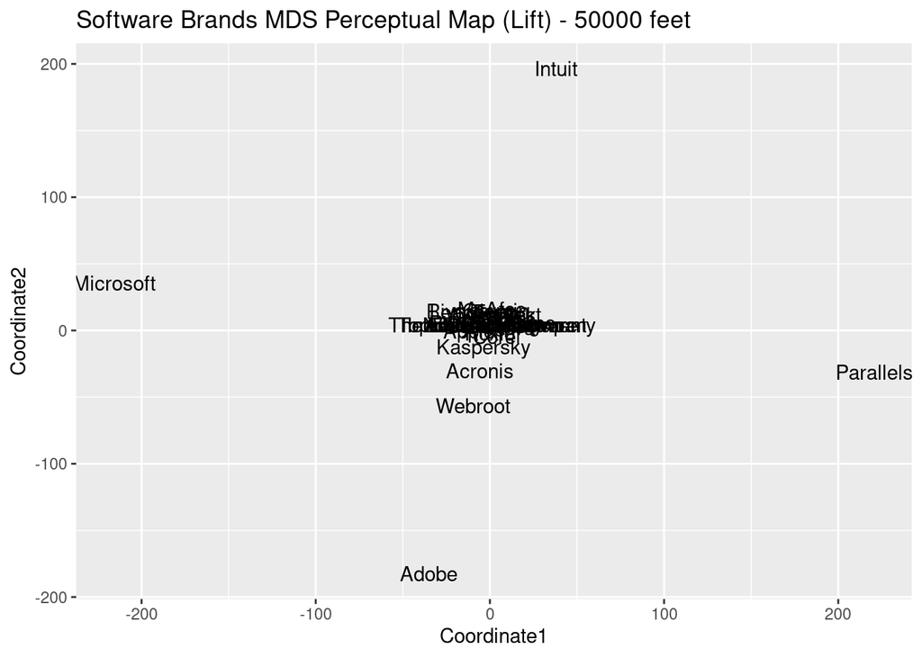

```r
write.csv(matrix2, file = "matrix2.csv")

tmp.df <- read.csv("matrix3.csv")
tmp.df <- tmp.df[,-1]
dat.df <- tmp.df[,-1]
rownames(dat.df) <- tmp.df[,1]


dat.df[is.na(dat.df)] <- 0
dat.df[dat.df == Inf] <- 0

dat.mat <- data.matrix(dat.df)
dat.mds <- cmdscale(dat.mat, eig=TRUE, k=2) #MDS,k=2 means two-dimensional

#save results in new dataset
result.mds = data.frame(dat.mds$points)
colnames(result.mds) = c("Coordinate1", "Coordinate2")

# plot solution, with zoomed in version
result.mds %>%
  ggplot(aes(x=Coordinate1,y=Coordinate2)) +
  labs(title="Software Brands MDS Perceptual Map (Lift) - 50000 feet") +
  geom_text(label=row.names(result.mds))
```

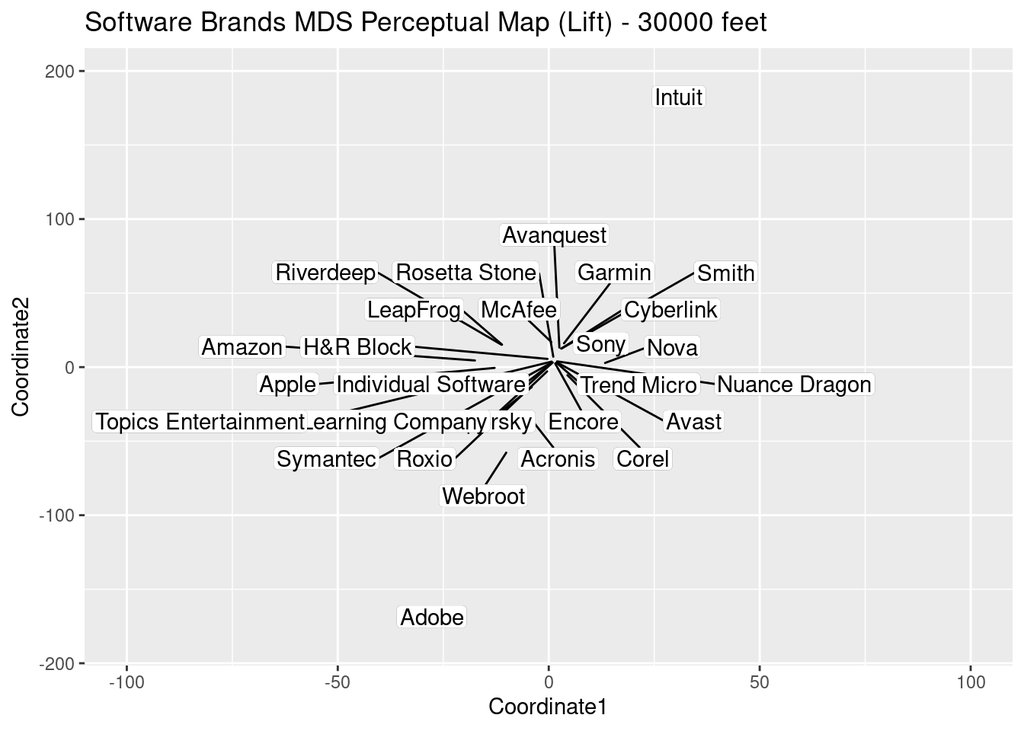

```r
result.mds %>%
  ggplot(aes(x=Coordinate1,y=Coordinate2)) +
  labs(title="Software Brands MDS Perceptual Map (Lift) - 30000 feet") +
  geom_label_repel(label=row.names(result.mds), label.size = 0.02, label.padding = 0.1, max.overlaps = 200) +
  xlim(-100,100)
```

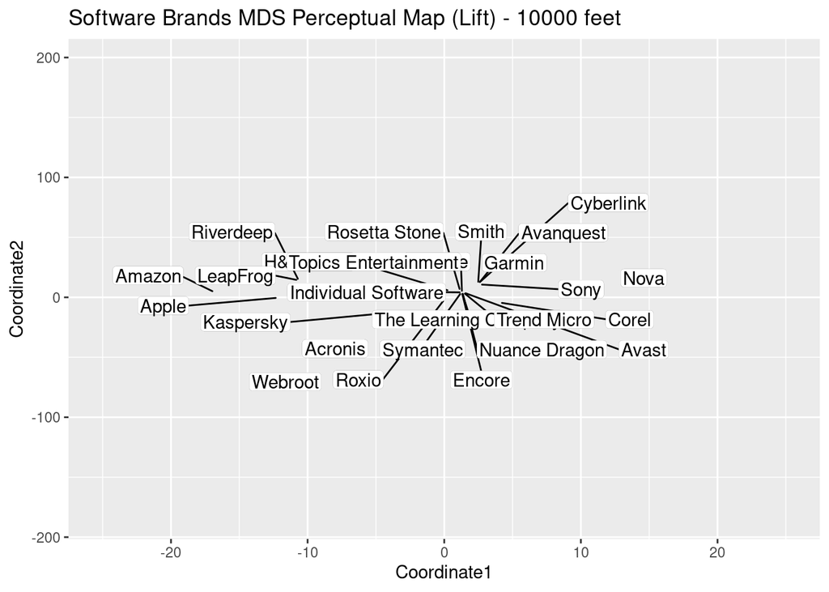

```r
result.mds %>%
  ggplot(aes(x=Coordinate1,y=Coordinate2)) +
  labs(title="Software Brands MDS Perceptual Map (Lift) - 10000 feet") +
  geom_label_repel(label=row.names(result.mds), label.size = 0.02, label.padding = 0.1, max.overlaps = 200) +
  xlim(-25,25)
```

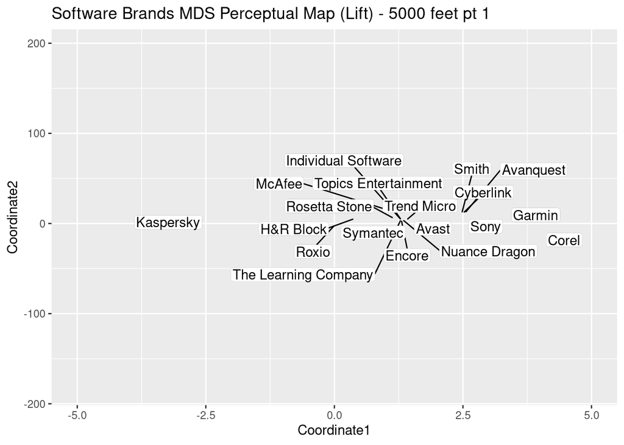

```r
result.mds %>%
  ggplot(aes(x=Coordinate1,y=Coordinate2)) +
  labs(title="Software Brands MDS Perceptual Map (Lift) - 5000 feet pt 1") +
  geom_label_repel(label=row.names(result.mds), label.size = 0.02, label.padding = 0.1, max.overlaps = 200) +
  xlim(-5,5)
```

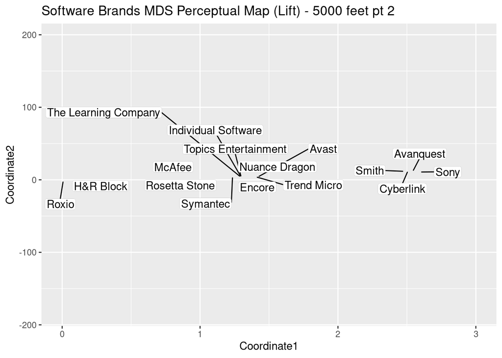

```r
result.mds %>%
  ggplot(aes(x=Coordinate1,y=Coordinate2)) +
  labs(title="Software Brands MDS Perceptual Map (Lift) - 5000 feet pt 2") +
  geom_label_repel(label=row.names(result.mds), label.size = 0.02, label.padding = 0.1, max.overlaps = 200) +
  xlim(0,3)
```